# Chapter 2: Regression analysis

This week I learned to do regression diagnostics with R and learned to use R-markdown a little more.

Data comes from international survey of Approaches to Learning.

## Exercise 1: structure of data

```r
student_2014<-read.table("http://s3.amazonaws.com/assets.datacamp.com/production/course_2218/datasets/learning2014.txt", header=TRUE, sep=",")
head(student_2014)
```

```
##   gender age attitude     deep  stra     surf points
## 1      F  53      3.7 3.583333 3.375 2.583333     25
## 2      M  55      3.1 2.916667 2.750 3.166667     12
## 3      F  49      2.5 3.500000 3.625 2.250000     24
## 4      M  53      3.5 3.500000 3.125 2.250000     10
## 5      M  49      3.7 3.666667 3.625 2.833333     22
## 6      F  38      3.8 4.750000 3.625 2.416667     21
```

```r
dim(student_2014)
```

```
## [1] 166   7
```

```r
str(student_2014)
```

```
## 'data.frame':    166 obs. of  7 variables:
##  $ gender  : Factor w/ 2 levels "F","M": 1 2 1 2 2 1 2 1 2 1 ...
##  $ age     : int  53 55 49 53 49 38 50 37 37 42 ...
##  $ attitude: num  3.7 3.1 2.5 3.5 3.7 3.8 3.5 2.9 3.8 2.1 ...
##  $ deep    : num  3.58 2.92 3.5 3.5 3.67 ...
##  $ stra    : num  3.38 2.75 3.62 3.12 3.62 ...
##  $ surf    : num  2.58 3.17 2.25 2.25 2.83 ...
##  $ points  : int  25 12 24 10 22 21 21 31 24 26 ...
```

The data includes 7 variables and 166 students. Variables include for example gender, age, attitude towards statistics and exam points.

## Exercise 2: more about structure of data

```r
summary(student_2014)
```

```
##  gender       age           attitude          deep            stra
##  F:110   Min.   :17.00   Min.   :1.400   Min.   :1.583   Min.   :1.250
##  M: 56   1st Qu.:21.00   1st Qu.:2.600   1st Qu.:3.333   1st Qu.:2.625
##          Median :22.00   Median :3.200   Median :3.667   Median :3.188
##          Mean   :25.51   Mean   :3.143   Mean   :3.680   Mean   :3.121
##          3rd Qu.:27.00   3rd Qu.:3.700   3rd Qu.:4.083   3rd Qu.:3.625
##          Max.   :55.00   Max.   :5.000   Max.   :4.917   Max.   :5.000
##       surf           points
##  Min.   :1.583   Min.   : 7.00
##  1st Qu.:2.417   1st Qu.:19.00
##  Median :2.833   Median :23.00
##  Mean   :2.787   Mean   :22.72
##  3rd Qu.:3.167   3rd Qu.:27.75
##  Max.   :4.333   Max.   :33.00
```

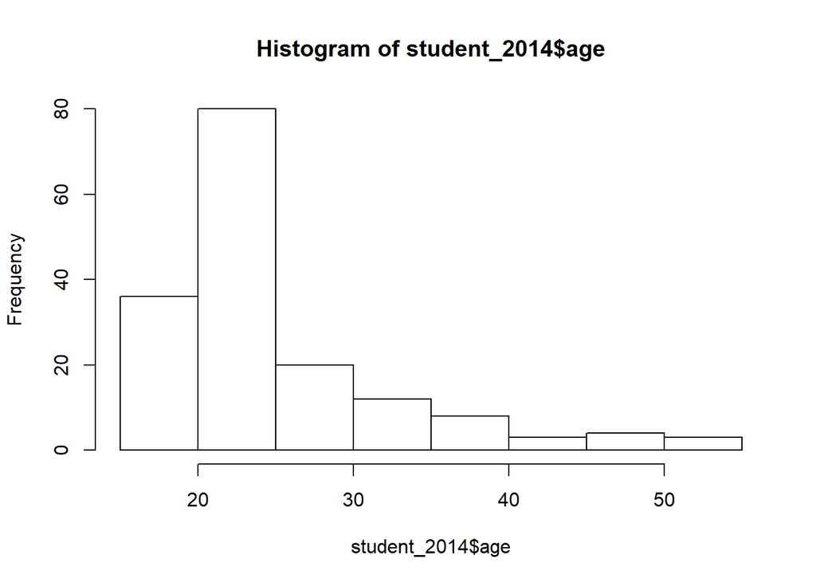

```r
hist(student_2014$age)
```

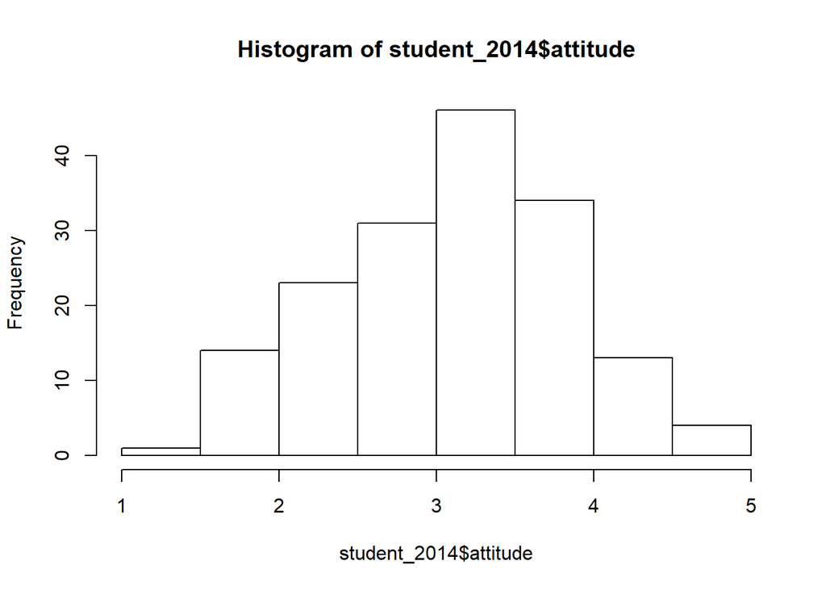

```r
hist(student_2014$attitude)
```

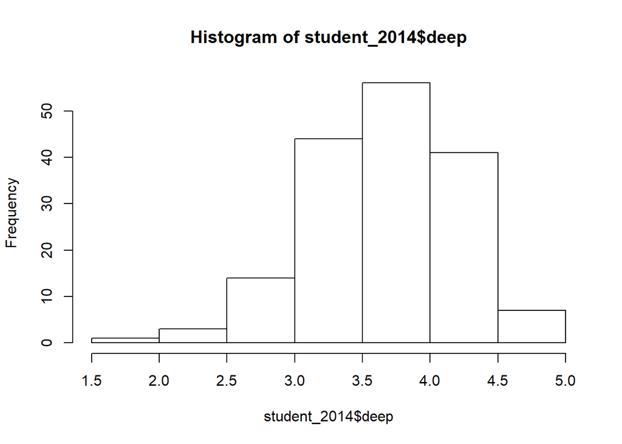

```r
hist(student_2014$deep)
```

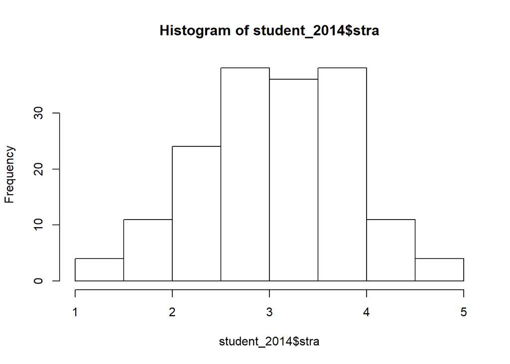

```r
hist(student_2014$stra)
```

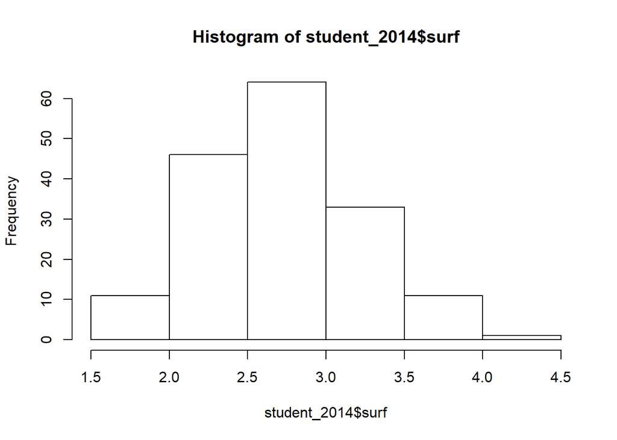

```r
hist(student_2014$surf)
```

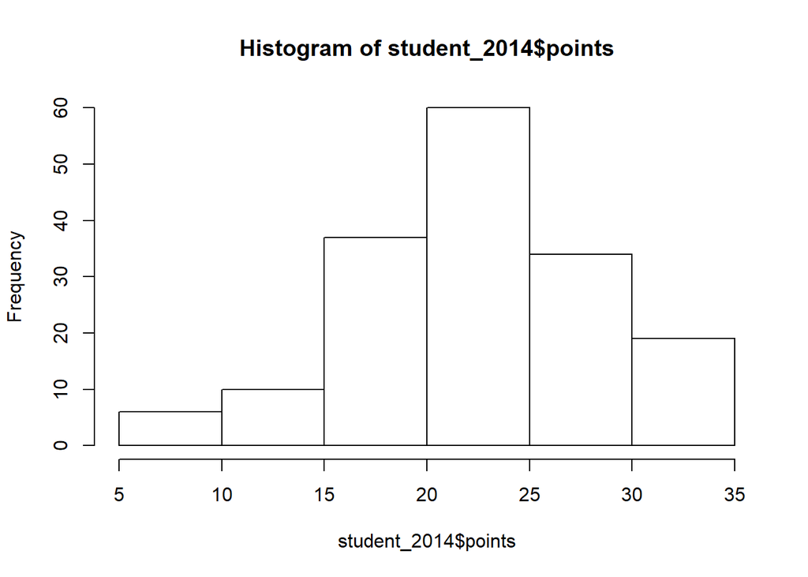

```r
hist(student_2014$points)
```

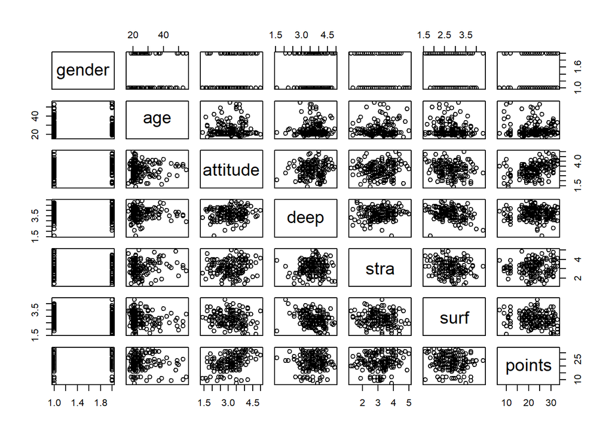

```r
pairs(student_2014)
```

Most students seem to be female and quite young. Points and attitudes seem to be quite normally distributed as the variables that measure deep-/strategic- and surface approach.

## Exercise 3: regression analysis

```r
fit<-lm(points~attitude+age+deep,data=student_2014)
fit
```

```
##
## Call:
## lm(formula = points ~ attitude + age + deep, data = student_2014)
##
## Coefficients:
## (Intercept)     attitude          age         deep
##    15.60773      3.59413     -0.07716     -0.60275
```

```r
summary(fit)
```

```
##
## Call:
## lm(formula = points ~ attitude + age + deep, data = student_2014)
##
## Residuals:
##     Min      1Q  Median      3Q     Max
## -17.206  -3.430   0.204   3.979  10.950
##
## Coefficients:
##             Estimate Std. Error t value Pr(>|t|)
## (Intercept) 15.60773    3.38966   4.605 8.32e-06 ***
## attitude     3.59413    0.56959   6.310 2.56e-09 ***
## age         -0.07716    0.05322  -1.450    0.149
## deep        -0.60275    0.75031  -0.803    0.423
## ---
## Signif. codes:  0 '***' 0.001 '**' 0.01 '*' 0.05 '.' 0.1 ' ' 1
##
## Residual standard error: 5.307 on 162 degrees of freedom
## Multiple R-squared:  0.2043, Adjusted R-squared:  0.1896
## F-statistic: 13.87 on 3 and 162 DF,  p-value: 4.305e-08
```

The only variable that has a statistically significant relation with exam points is the attitude-variable. Age and deep approach do not have a statistically significant relationship with exam points.

```r
fit2<-lm(points~attitude, data=student_2014)
fit2
```

```
##
## Call:
## lm(formula = points ~ attitude, data = student_2014)
##
## Coefficients:
## (Intercept)     attitude
##      11.637        3.525
```

```r
summary(fit2)
```

```
##
## Call:
## lm(formula = points ~ attitude, data = student_2014)
##
## Residuals:
##      Min       1Q   Median       3Q      Max
## -16.9763  -3.2119   0.4339   4.1534  10.6645
##
## Coefficients:
##             Estimate Std. Error t value Pr(>|t|)
## (Intercept)  11.6372     1.8303   6.358 1.95e-09 ***
## attitude      3.5255     0.5674   6.214 4.12e-09 ***
## ---
## Signif. codes:  0 '***' 0.001 '**' 0.01 '*' 0.05 '.' 0.1 ' ' 1
##
## Residual standard error: 5.32 on 164 degrees of freedom
## Multiple R-squared:  0.1906, Adjusted R-squared:  0.1856
## F-statistic: 38.61 on 1 and 164 DF,  p-value: 4.119e-09
```

## Exercise 4: interpreting model parameters

The only explanatory varialbe, attitude, is a significant predictor of exam points (p -value close to 0.) When attitude increases one point, exam points increases on average 3.5255 points. Multiple R-square is 0.1906, meaning that the attitude variable can explain about one fifth of the variance in exam points, which is fairly good.

## Exercise 5: assumptions of regression model

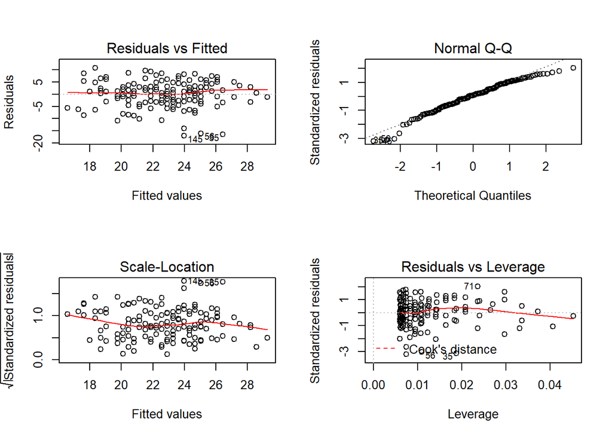

```r
par(mfrow=c(2,2))
plot(fit2)
```

When looking at fitted values vs. residuals one can see whether there are non-linear patterns. In this case there are not. When looking at normal Q-Q -plot we can see that whether residuals are normally distributed. In this case they are. Scale location -plot shows that residuals are also spread equally along the ranges of predictors. Residuals vs. leverage -plot shows whether there are influential cases against the regression line. In this case there are not.

So, we can say that regression model is a suitable method with this data.